# Signal Validation & Statistical Rigour

**Research question.** Do our alpha signals hold up under proper statistical correction, and can we recover Bollinger's edge by matching rebalance frequency to signal horizon?

## Context

Notebook 02 identified two surviving factors, **Momentum 12-1** and **Bollinger**, but flagged methodology problems:

1. **Overlapping forward returns inflated t-statistics by ~4.6x.** The reported t-stats assumed independent daily observations, but 21d forward returns share 20/21 days between consecutive dates.
2. **Bollinger's IC-to-P&L gap:** strongest IC yet worst backtest (Sharpe −0.93). Daily rebalancing generated turnover costs that removed the edge.
3. **Regime dependence:** Momentum's IC was far stronger post-2024 than pre-2024.

This notebook applies the validation module built in Phase 2.5, on a larger 50-stock universe, to answer: after correction, which signals are real, and can implementation close the gap?

## Dropped factors

- **XS Momentum:** redundant (identical IC to raw Momentum, weaker backtest due to rank compression).
- **RSI:** insignificant IC at every horizon, high correlation with Bollinger (0.88), no robustness.

## 0. Setup

## 1. Data & Signal Generation

```
Fetching 33 new tickers: ['AVGO', 'ADBE', 'CRM', 'BAC', 'WFC', 'MS', 'BLK', 'PFE', 'ABT', 'LLY', 'TMO', 'TSLA', 'HD', 'NKE', 'MCD', 'KO', 'PEP', 'COST', 'CVX', 'COP', 'CAT', 'HON', 'UPS', 'RTX', 'MA', 'NFLX', 'DIS', 'NEE', 'DUK', 'AMT', 'PLD', 'LIN', 'SHW']
Done.

Universe: 47 tickers
Period: 2020-01-02 to 2026-05-15
Shape: 1601 days x 47 tickers
Missing: 0 NaNs

Momentum 12-1: first signal 2020-12-31, 63,403 values
Bollinger: first signal 2020-01-30, 74,354 values
```

## 2. Signal Diagnostics

Before any IC analysis, we characterize the signals themselves. Four questions:

- **Autocorrelation:** How sticky is the signal day-to-day? (quasi-static = daily rebalancing is churn)
- **Turnover:** How much do implied weights change daily? (low = rebalance less often)
- **Dispersion:** Does the signal differentiate stocks? (near-zero = no positions after neutralization)
- **Lead-lag:** Is the signal predictive or reactive? (negative-offset correlation = echoing past returns)

### 2a. Signal Autocorrelation

```
Momentum 12-1 lag-1 autocorrelation: 0.9903
Bollinger lag-1 autocorrelation: 0.8677
```

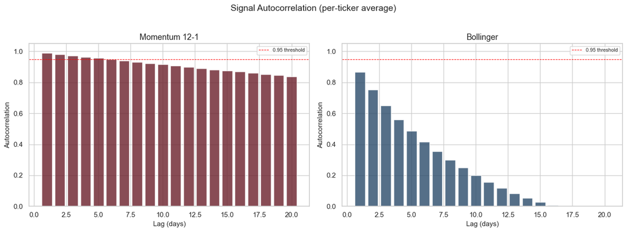

**Observations: autocorrelation.**

- **Momentum (lag-1 = 0.990):** extremely persistent, above the 0.95 quasi-static threshold through ~lag 6. A 252-day lookback shares 251/252 days between consecutive dates, so daily rebalancing would generate turnover for near-zero position change. This signal should be rebalanced infrequently.
- **Bollinger (lag-1 = 0.868):** decays faster, dropping below 0.50 by lag 5 and toward zero by lag 15. A 20-day window lets the signal flip within a few days as prices cross the bands. It can rebalance frequently, but as later sections show there is no predictive power to exploit at any frequency.
- **Implication:** Momentum should rebalance on the order of weeks to reduce cost drag. For Bollinger, the autocorrelation structure does not matter; frequency and smoothing only control transaction costs rather than how much alpha is captured, since there is no detectable alpha.

### 2b. Signal Turnover & Dispersion

```
Momentum 12-1 mean turnover: 0.0940
Momentum 12-1 mean dispersion: 0.3273
Bollinger mean turnover: 0.4369
Bollinger mean dispersion: 1.0955
```

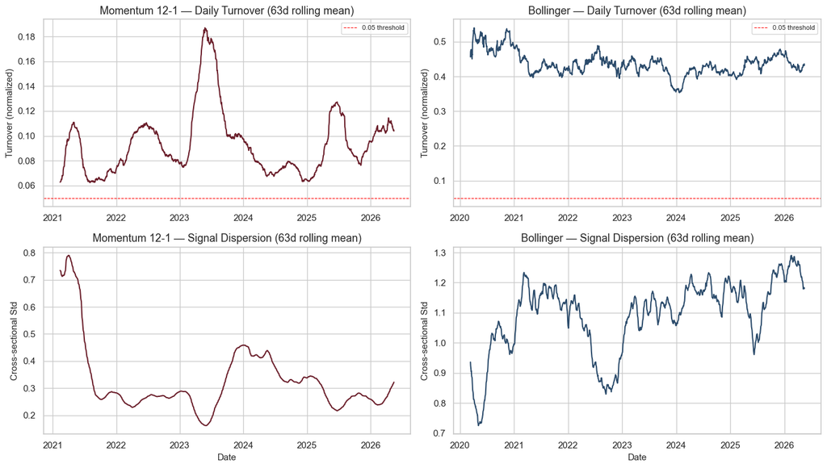

### 2c. Lead-Lag Profile

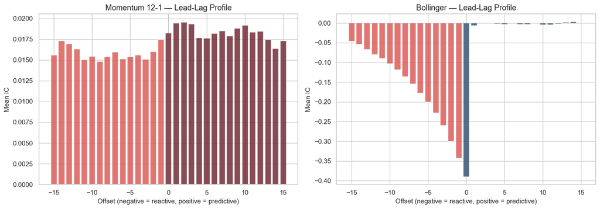

**Observations: lead-lag profile.**

- **Momentum:** all bars positive and nearly symmetric across reactive (negative offsets) and predictive (positive offsets) sides, around IC 0.015-0.020. This is consistent with a persistent factor: momentum stocks tend to keep outperforming regardless of the measurement window. The symmetry means the signal captures a slow-moving characteristic rather than being purely predictive or purely reactive.
- **Bollinger:** strong negative IC on the reactive side (offsets −15 to 0), peaking at offset 0 with IC ~ −0.40; the predictive side (offsets +1 to +15) is near zero. This is mean-reversion mechanics by construction: Bollinger z-scores are high when price is above the band (after a run-up), so the signal is mechanically anti-correlated with recent returns. The near-zero predictive side indicates **Bollinger has no detectable forward-looking edge at any short-term horizon.**
- **The lead-lag profile separates mechanical correlation from genuine prediction.** Bollinger's reactive side is a construction artefact (a z-score from recent prices correlates with those recent returns); the predictive side is what matters, and it is flat.

## 3. Corrected IC Analysis

Standard t-statistics assume independent daily IC observations. With overlapping forward returns (a 21d horizon shares 20/21 days between consecutive dates), this overstates significance by ~√h. We apply three corrections:

1. **Newey-West HAC t-statistic:** adjusts standard errors for autocorrelation (bandwidth = horizon − 1).
2. **Non-overlapping IC:** samples every h-th day for independent observations.
3. **Block bootstrap 95% CI:** preserves serial dependence to give honest confidence intervals.

IC Summary — Naive vs Newey-West Corrected

|  | Factor | Horizon | Mean IC | ICIR | t (naive) | t (NW) | Inflation | 95% CI |
| --- | --- | --- | --- | --- | --- | --- | --- | --- |
| 0 | Momentum 12-1 | 1d | 0.0195 | 0.064 | 2.35 | 2.35 | 1.0x | [+0.0030, +0.0354] |
| 1 | Momentum 12-1 | 5d | 0.0226 | 0.077 | 2.82 | 1.57 | 1.8x | [-0.0054, +0.0508] |
| 2 | Momentum 12-1 | 10d | 0.0237 | 0.085 | 3.12 | 1.29 | 2.4x | [-0.0122, +0.0593] |
| 3 | Momentum 12-1 | 21d | 0.0307 | 0.122 | 4.43 | 1.28 | 3.5x | [-0.0174, +0.0771] |
| 4 | Bollinger | 1d | -0.0061 | -0.023 | -0.91 | -0.91 | 1.0x | [-0.0194, +0.0068] |
| 5 | Bollinger | 5d | -0.0052 | -0.021 | -0.84 | -0.50 | 1.7x | [-0.0259, +0.0148] |
| 6 | Bollinger | 10d | 0.0007 | 0.003 | 0.12 | 0.06 | 2.1x | [-0.0240, +0.0264] |
| 7 | Bollinger | 21d | 0.0094 | 0.041 | 1.61 | 0.63 | 2.5x | [-0.0180, +0.0399] |

**Observations: corrected IC.**

- **Inflation scales with horizon as expected.** At 1d there is no overlap, so naive = NW (1.0x). At 21d the inflation is 3.5x for Momentum, close to the theoretical √21 ≈ 4.6x; the gap from theory is because the IC series is not perfectly autocorrelated.
- **Momentum's naive t = 4.43 at 21d falls to 1.28 after NW correction**, below the 95% threshold, and the bootstrap CI [−0.017, +0.077] straddles zero. The signal that looked strong in NB02 is marginal after correction.
- **Bollinger is insignificant at every horizon after correction.** Best case (21d): t(NW) = 0.63, CI [−0.018, +0.040]. The daily IC is slightly negative (−0.006), consistent with the lead-lag finding.
- **Momentum's mean IC rises with horizon** (0.020 at 1d to 0.031 at 21d), consistent with a slow-moving signal, but statistical confidence falls because the NW correction grows harsher as overlap increases.
- **Reality check:** these are crude, well-known factors on a survivorship-biased universe. Marginal significance is the expected outcome; the NB02 results were inflated by overlapping returns treated as independent observations.

## 4. Non-Overlapping IC

An alternative to Newey-West: sample every h-th day so return windows are completely disjoint. Fewer observations (~65 at the 21d horizon vs ~1,300 daily), but each is genuinely independent.

Daily vs Non-Overlapping IC Comparison

|  | Factor | Horizon | Daily Mean IC | Daily N | Daily t | Non-Overlap Mean IC | Non-Overlap N | Non-Overlap t |
| --- | --- | --- | --- | --- | --- | --- | --- | --- |
| 0 | Momentum 12-1 | 1d | 0.0195 | 1348 | 2.35 | 0.0195 | 1348 | 2.35 |
| 1 | Momentum 12-1 | 5d | 0.0226 | 1344 | 2.82 | 0.0195 | 269 | 1.14 |
| 2 | Momentum 12-1 | 10d | 0.0237 | 1339 | 3.12 | 0.0205 | 134 | 0.89 |
| 3 | Momentum 12-1 | 21d | 0.0307 | 1328 | 4.43 | 0.0266 | 64 | 0.78 |
| 4 | Bollinger | 1d | -0.0061 | 1581 | -0.91 | -0.0061 | 1581 | -0.91 |
| 5 | Bollinger | 5d | -0.0052 | 1577 | -0.84 | -0.0130 | 316 | -0.96 |
| 6 | Bollinger | 10d | 0.0007 | 1572 | 0.12 | -0.0061 | 158 | -0.33 |
| 7 | Bollinger | 21d | 0.0094 | 1561 | 1.61 | 0.0062 | 75 | 0.21 |

**Observations: non-overlapping IC.**

- **At 1d, daily = non-overlapping** (N = 1,348 both ways, t = 2.35). No overlap means no correction needed, a useful sanity check.
- **Momentum 21d: N drops from 1,328 to 64** independent observations. Mean IC barely changes (0.031 → 0.027), but t collapses from 4.43 to 0.78. With ~64 draws there is not enough power to detect a signal this weak.
- **Bollinger 21d: mean IC drops from 0.009 to 0.006**, t = 0.21, indistinguishable from noise.
- **Non-overlapping agrees with NW directionally** (neither signal is significant at 21d) but is more pessimistic due to the sample reduction. The effective sample size at 21d is ~1,328/21 ≈ 63, almost matching the non-overlapping N = 64, which confirms the NW inflation estimate is well-calibrated.
- **Tradeoff:** NW keeps all observations and adjusts standard errors (more power, model-dependent); non-overlapping uses independent observations only (less power, assumption-free). When both agree, the conclusion is trustworthy.

## 5. IC Decay with Bootstrap Confidence Intervals

The IC decay curve shows mean IC at each forward horizon, but without error bars it is impossible to tell signal from noise. Block bootstrap 95% CIs show which lags are significant and where the peak is.

```
Momentum 12-1: IC peaks at lag 15d with mean IC = 0.0327
Bollinger: IC peaks at lag 29d with mean IC = 0.0129
```

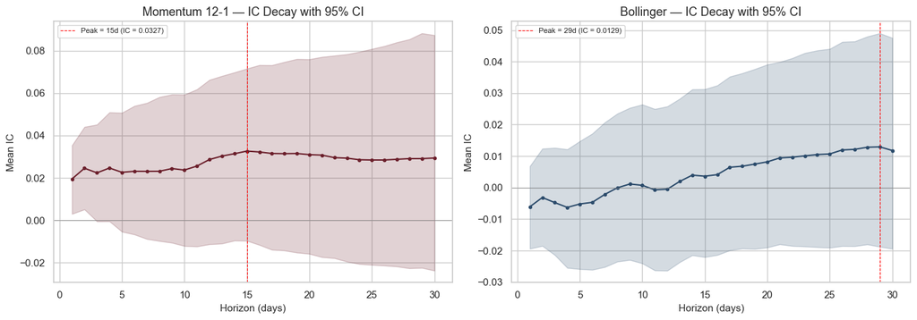

**Observations: IC decay.**

- **Momentum peaks at lag 15d** (mean IC 0.033). Built from a 252d lookback, it captures a slow-moving characteristic, but the predictive sweet spot is ~3 weeks. Beyond 15d, IC holds roughly flat through lag 30. The bootstrap CIs from Section 3 show this IC is not significant after NW correction (t = 1.28 at 21d), so the peak should be read cautiously.
- **Bollinger peaks at lag 29d** (mean IC 0.013), but the CI band contains zero at every lag (consistent with t(NW) = 0.63 at 21d). The apparent peak is estimation noise drifting upward at the boundary of the test range.
- **Natural rebalance frequencies:** Momentum 15d, Bollinger 29d. These feed the backtest in Section 6, though for Bollinger the natural frequency is just the lag where noise was highest.
- **The decay shape is a useful diagnostic.** Momentum has a shallow hump suggesting some horizon structure, even if marginal; Bollinger's curve is flat noise, with the upward drift an artefact of sampling variability at longer lags.

## 6. Backtest: Daily vs Natural Frequency

The key test: does matching rebalance frequency to the IC decay peak recover Bollinger's edge, and does momentum benefit from less frequent rebalancing (lower costs)?

```
Momentum 12-1: natural rebalance frequency = 15d
Bollinger: natural rebalance frequency = 29d
```

Backtest Sharpe by Rebalance Frequency (10 bps cost)

|  | Factor | Rebal Freq | Ann. Return (%) | Ann. Vol (%) | Sharpe | Natural |
| --- | --- | --- | --- | --- | --- | --- |
| 0 | Momentum 12-1 | 1d | 3.74 | 11.29 | +0.332 |  |
| 1 | Momentum 12-1 | 5d | 3.62 | 11.32 | +0.320 |  |
| 2 | Momentum 12-1 | 10d | 3.61 | 11.27 | +0.321 |  |
| 3 | Momentum 12-1 | 15d | 4.81 | 11.33 | +0.425 | <<< |
| 4 | Momentum 12-1 | 21d | 3.70 | 11.24 | +0.330 |  |
| 5 | Bollinger | 1d | -14.98 | 9.48 | -1.581 |  |
| 6 | Bollinger | 5d | -7.96 | 8.95 | -0.890 |  |
| 7 | Bollinger | 10d | -5.55 | 8.32 | -0.668 |  |
| 8 | Bollinger | 15d | -3.23 | 8.36 | -0.386 |  |
| 9 | Bollinger | 21d | -0.34 | 8.85 | -0.038 |  |

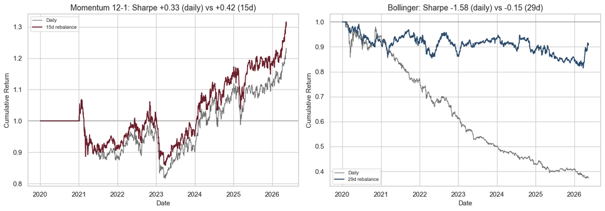

## 7. Backtest with Position Smoothing

Beyond rebalance frequency, position smoothing offers a second lever to reduce turnover. Instead of snapping to the new target on rebalance days, we blend: `position = α × target + (1-α) × yesterday`. This softens position transitions and reduces round-trip costs.

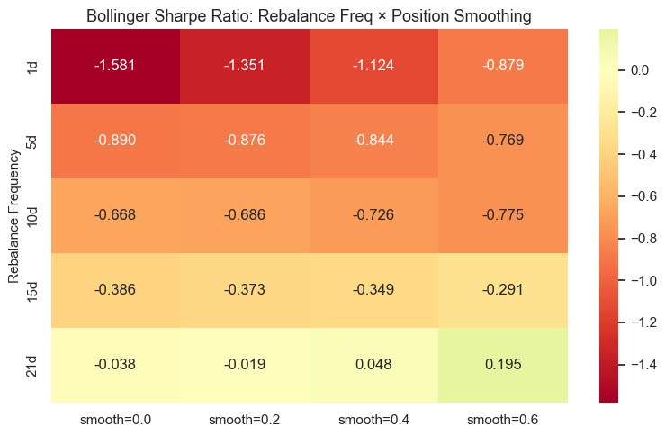

```
Best Bollinger combo: freq=21d, smooth=0.6, Sharpe=+0.195
```

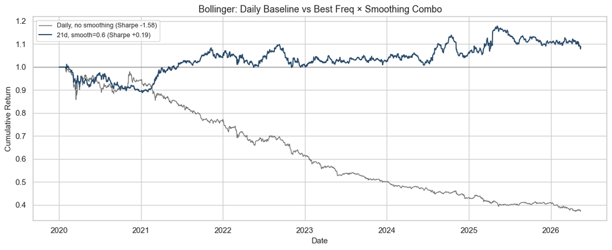

## 8. Robustness Tests

Four tests to challenge whether the corrected findings hold up:

1. **Sub-period split:** does IC persist in both halves (pre/post 2024)?
2. **Leave-one-out:** does removing NVDA or the most volatile stock destroy the signal?
3. **Sector split:** does the signal work within tech and non-tech separately?
4. **Parameter sensitivity:** is momentum IC stable across lookback windows?

### 8a. Sub-Period Stability

Sub-Period IC Stability (NW-corrected)

|  | Factor | Period | Mean IC | t (naive) | t (NW) | N dates |
| --- | --- | --- | --- | --- | --- | --- |
| 0 | Momentum 12-1 | Full | 0.0307 | 4.43 | 1.28 | 1328 |
| 1 | Momentum 12-1 | Pre-2024 | 0.0052 | 0.57 | 0.17 | 754 |
| 2 | Momentum 12-1 | Post-2024 | 0.0643 | 6.11 | 1.83 | 574 |
| 3 | Bollinger | Full | 0.0094 | 1.61 | 0.63 | 1561 |
| 4 | Bollinger | Pre-2024 | 0.0124 | 1.73 | 0.74 | 987 |
| 5 | Bollinger | Post-2024 | 0.0043 | 0.43 | 0.15 | 574 |

**Observations: sub-period stability.**

### 8b. Leave-One-Out

```
Most volatile (excl. NVDA): TSLA
```

Leave-One-Out IC (NW-corrected, at 21d horizon)

|  | Condition | Factor | Mean IC | t (NW) | N tickers |
| --- | --- | --- | --- | --- | --- |
| 0 | Full (50) | Momentum 12-1 | 0.0307 | 1.28 | 47 |
| 1 | Full (50) | Bollinger | 0.0094 | 0.63 | 47 |
| 2 | No NVDA | Momentum 12-1 | 0.0274 | 1.18 | 46 |
| 3 | No NVDA | Bollinger | 0.0093 | 0.65 | 46 |
| 4 | No TSLA | Momentum 12-1 | 0.0343 | 1.39 | 46 |
| 5 | No TSLA | Bollinger | 0.0121 | 0.80 | 46 |

**Observations: leave-one-out.**

- **Neither signal is driven by a single name.** Removing NVDA barely changes Momentum (IC 0.031 → 0.027, t(NW) 1.28 → 1.18) or Bollinger (0.009 → 0.009, t(NW) 0.63 → 0.65). Removing TSLA (most volatile ex-NVDA) slightly improves both (Momentum t(NW) rises to 1.39), suggesting TSLA's volatility adds noise to the cross-sectional correlation.
- **This is reassuring for portfolio construction.** With 47 stocks, no single name dominates the IC. This is an advantage of the larger universe over the 14-stock NB02 setup, where single-name effects were more pronounced.

### 8c. Sector Split

IC by Sector (NW-corrected, at 21d horizon) — sectors with N >= 5 only

|  | Sector | N tickers | Factor | Mean IC | t (NW) |
| --- | --- | --- | --- | --- | --- |
| 0 | Tech | 8 | Momentum 12-1 | 0.0760 | 1.88 |
| 1 | Tech | 8 | Bollinger | 0.0080 | 0.32 |
| 2 | Financials | 6 | Momentum 12-1 | 0.0217 | 0.47 |
| 3 | Financials | 6 | Bollinger | 0.0398 | 1.55 |
| 4 | Healthcare | 6 | Momentum 12-1 | 0.0546 | 1.30 |
| 5 | Healthcare | 6 | Bollinger | 0.0182 | 0.70 |
| 6 | Cons. Disc. | 5 | Momentum 12-1 | 0.0284 | 0.58 |
| 7 | Cons. Disc. | 5 | Bollinger | 0.0004 | 0.01 |
| 8 | Cons. Staples | 5 | Momentum 12-1 | 0.1179 | 2.36 |
| 9 | Cons. Staples | 5 | Bollinger | 0.0087 | 0.25 |
| 10 | Other | 10 | Momentum 12-1 | -0.0388 | -1.04 |
| 11 | Other | 10 | Bollinger | -0.0023 | -0.10 |

**Observations: sector split.**

- **Momentum works in some sectors but not others.** Strongest in Consumer Staples (IC 0.118, t(NW) 2.36, the only sector-level significance) and Tech (IC 0.076, t(NW) 1.88); weakest in Other (IC −0.039, t(NW) −1.04, slightly negative). Momentum captures slow-moving sector trends (staples trending steadily, tech during the AI run-up) but fails in heterogeneous groups.
- **Bollinger is insignificant in every sector.** Best case is Financials (IC 0.040, t(NW) 1.55), still below the bar.
- **Small cross-sections weaken IC.** Sectors with 5-6 stocks have noisy rank correlations, where a single outlier can dominate. The Tech (8 stocks) and Other (10 stocks) results are more reliable than Cons. Disc. (5 stocks). Read the Consumer Staples result with caution: 5 defensive names in a bull market will show strong momentum almost by construction.

### 8d. Momentum Parameter Sensitivity

Momentum IC by Lookback Window (NW-corrected)

| Horizon Window | Mean IC 10d | Mean IC 21d | t (NW) 10d | t (NW) 21d |
| --- | --- | --- | --- | --- |
| 126d | 0.002 | -0.008 | 0.108 | -0.336 |
| 189d | 0.005 | -0.001 | 0.252 | -0.043 |
| 252d | 0.024 | 0.031 | 1.287 | 1.281 |
| 378d | 0.034 | 0.047 | 1.621 | 1.552 |
| 504d | 0.020 | 0.024 | 0.917 | 0.790 |
| 63d | -0.009 | -0.004 | -0.517 | -0.171 |

## 9. Updated Decision Table

Incorporating all corrections and robustness checks: Newey-West t-stats, natural-frequency backtests, sub-period stability, leave-one-out, and sector analysis.

Updated Decision Table — Corrected Statistics

| Factor | Natural Freq | Mean IC (21d) | t (NW) | Sharpe (daily) | Sharpe (natural) | Lag-1 Autocorr | Decision | Reason |
| --- | --- | --- | --- | --- | --- | --- | --- | --- |
| Momentum 12-1 | 15d | 0.0307 | 1.28 | +0.332 | +0.425 | 0.9903 | Discard | t(NW) < 2, regime-dependent, no sector consistency |
| Bollinger | 29d | 0.0094 | 0.63 | -1.581 | -0.145 | 0.8677 | Discard | IC insignificant at all horizons, no alpha after cost control |

## 10. Conclusion

**Both signals are discarded.** After applying proper statistical corrections (Newey-West HAC t-statistics, non-overlapping IC, block bootstrap confidence intervals), neither Momentum 12-1 nor Bollinger z-score survives as a tradeable alpha source.

### What we found

|  | Momentum 12-1 | Bollinger |
| --- | --- | --- |
| **Corrected t(NW) at 21d** | 1.28 | 0.63 |
| **Bootstrap 95% CI** | Straddles zero | Straddles zero |
| **Sub-period stability** | Regime-dependent (pre-2024 t=0.17, post-2024 t=1.83) | Insignificant in both halves |
| **Sector consistency** | Works in staples/tech, fails elsewhere | Insignificant in every sector |
| **Best Sharpe after optimization** | +0.42 (15d rebal) | +0.20 (21d rebal, smooth=0.6) |
| **Source of improvement** | Reduced trading cost | Reduced trading cost |

### Why NB02's results were misleading

1. **Overlapping returns inflated t-statistics by ~3.5x.** Momentum's naive t = 4.43 at 21d falls to 1.28 after NW correction. The statistical case did not survive once we accounted for the 20/21-day overlap between consecutive observations.
2. **Bollinger's IC-to-P&L gap reflected an absence of signal rather than an implementation problem.** The high IC at longer horizons (NB02) was noise that happened to look structured. Position smoothing and frequency matching improved Sharpe only by reducing trading cost, rather than by capturing predictive power.
3. **Momentum's post-2024 strength is a single-regime effect.** A calm, directional bull market is where naive momentum thrives; the pre-2024 period (COVID crash, 2022 bear, whipsaw recovery) showed IC indistinguishable from zero.

### What we learned (methodology)

- **NW correction is necessary** for overlapping forward returns. Without it, every slow-moving signal looks significant.
- **IC decay + bootstrap CIs** separate real horizon structure from estimation noise. A peak without a CI is meaningless.
- **Better Sharpe from less trading is not signal recovery.** The monotonic Sharpe improvement with lower frequency is a cost gradient rather than an alpha signature; a real signal would show a peak at its natural horizon rather than improving monotonically toward trading as little as possible.
- **Sub-period and sector splits** are cheap robustness checks that catch regime dependence early.

### Next steps

These signals served as a test bed for the validation framework. The toolkit (corrected IC, bootstrap CIs, IC decay, lead-lag profiles, robustness battery) is now tested and ready for signals that might work. Phase 3 focuses on sourcing more sophisticated alphas where this framework can distinguish real edges from noise.

## 9b. Tearsheets: Best Parameters (In-Sample Backtest)

Full performance tearsheets for each signal at its best configuration in this notebook. **These are in-sample backtest results rather than live, out-of-sample, or paper-traded performance.** The validation in Sections 3-8 shows neither signal is statistically significant after correction; the metrics below describe what happened historically rather than what to expect going forward.

- **Momentum 12-1:** 15d rebalance, no smoothing (Sharpe +0.42).
- **Bollinger:** 21d rebalance, smooth=0.6 (Sharpe +0.20).

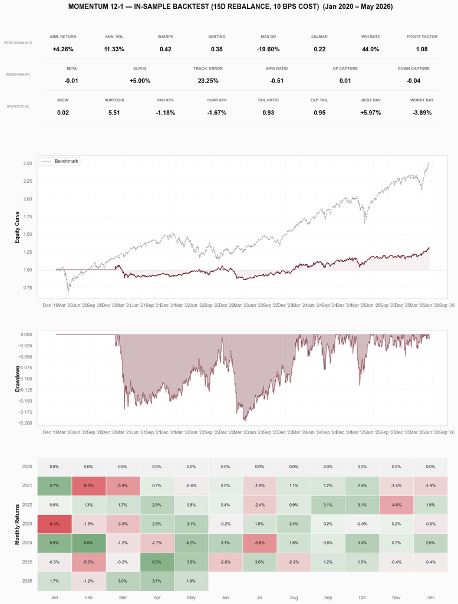

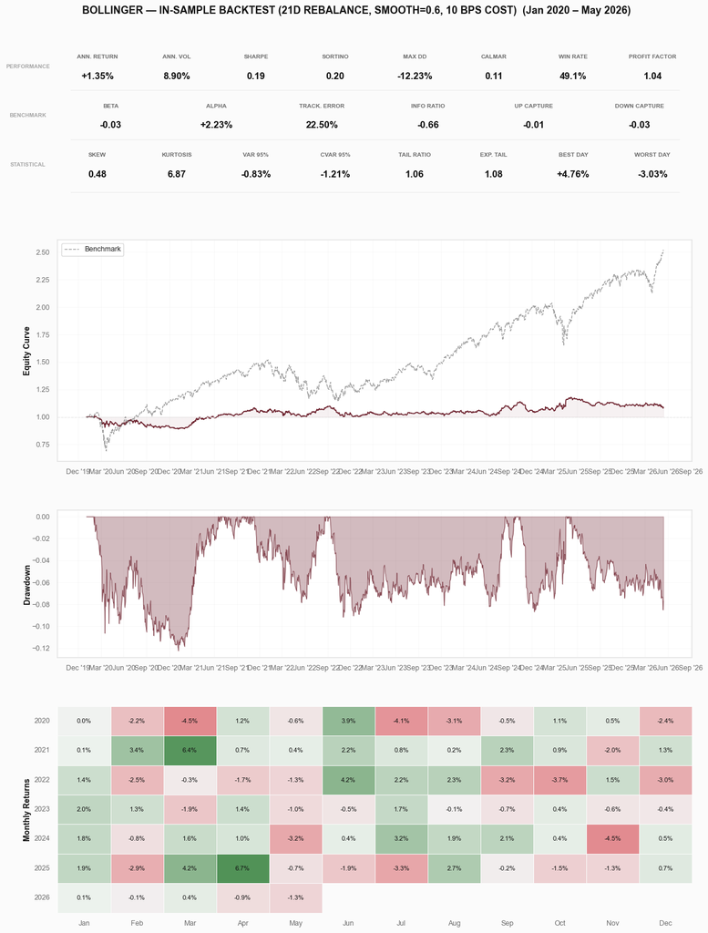